# Project1 - Course5: Reproducible Research

Cathy Gao

2019-03-23

## Loading and preprocessing the data

```r
unzip(zipfile="activity.zip")
activity<-read.csv("activity.csv", header=TRUE)
activity$date<-as.Date(as.character(activity$date), "%Y-%m-%d")
activity$interval<-as.factor(activity$interval)
str(activity$interval)
```

```
##  Factor w/ 288 levels "0","5","10","15",..: 1 2 3 4 5 6 7 8 9 10 ...
```

## What is mean total number of steps taken per day?

```r
sum.step<-with(activity, tapply(steps, date, sum))
summary(sum.step)
```

```
##    Min. 1st Qu.  Median    Mean 3rd Qu.    Max.    NA's
##      41    8841   10765   10766   13294   21194       8
```

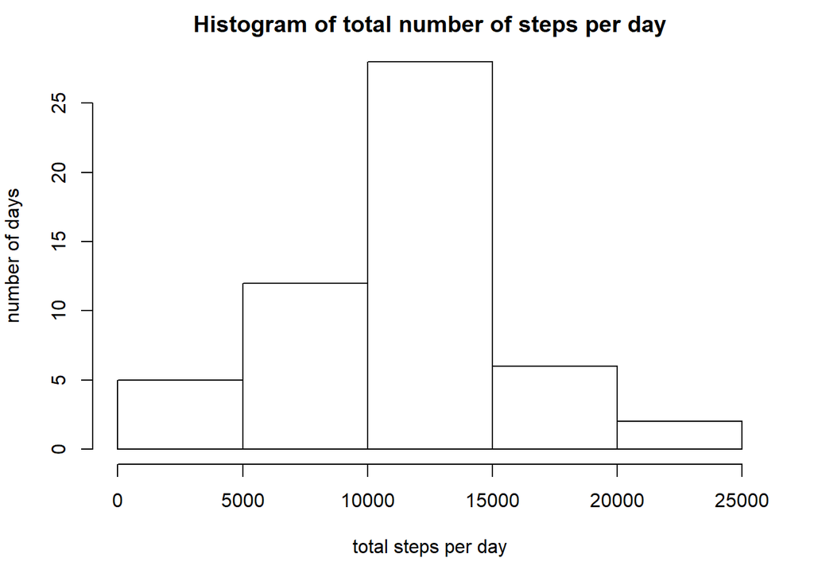

```r
# histogram of total steps per day
par(mar=c(5,4,2,2))
hist(sum.step, main="Histogram of total number of steps per day", xlab="total steps per day", ylab="number of days")
```

```r
# report the mean and median
mean(sum.step, na.rm=TRUE)
```

```
## [1] 10766.19
```

```r
median(sum.step, na.rm=TRUE)
```

```
## [1] 10765
```

## What is the average daily activity pattern?

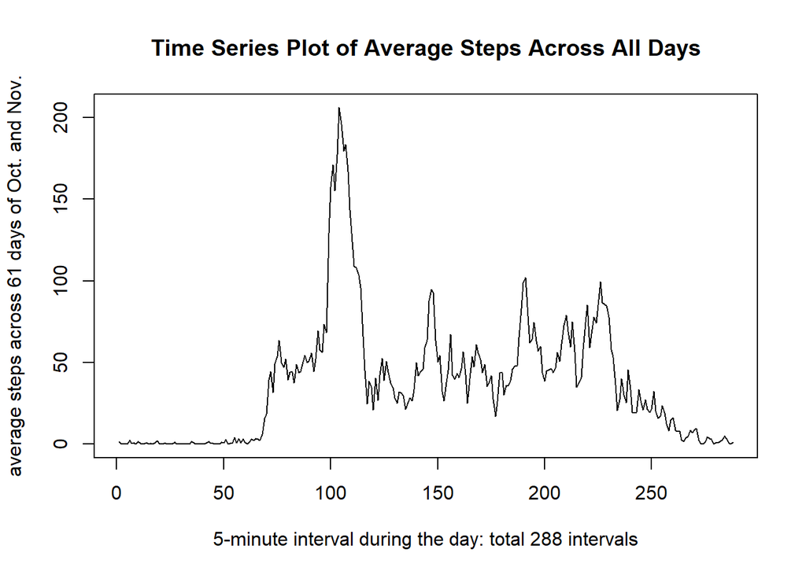

```r
mean.step<-aggregate(steps ~ interval, data=activity, mean, na.rm=TRUE)

# a time series plot of the 5-minute interval and the average number of steps across all days
with(mean.step, plot(steps, type="l", xlab="5-minute interval during the day: total 288 intervals", ylab="average steps across 61 days of Oct. and Nov.", main="Time Series Plot of Average Steps Across All Days"))
```

```r
# time interval of maximal steps averaged across day
mean.max<-mean.step[which.max(mean.step$steps), ]
```

At 835, the individual walked 206.1698113 steps on average across all the days in the dataset.

## Inputing missing values

There are a number of days/intervals where steps are missing values (coded as NA).  
1. Calculate and report the total number of missing values in the dataset (number of rows with NAs).

```r
list_na<-colnames(activity)[apply(activity, 2, anyNA)]
#sum(is.na(activity[,colnames(activity) %in% list_na]))
missing.no<-dim(activity[rowSums(is.na(activity))>0, ])[1]
missing.date<-unique(activity[is.na(activity$steps), "date"])
```

Missing values are from the variable(s) steps.  
There are 2304 missing observations.  
They are from 2012-10-01, 2012-10-08, 2012-11-01, 2012-11-04, 2012-11-09, 2012-11-10, 2012-11-14, 2012-11-30.

2/3. Devise a strategy for filling in the missing values and create the new dataset with the missing values filled in.  
* Strategy: use the mean of the interval

```r
replace.missing.mean<-function(x){
    x[is.na(x)]<-mean(x, na.rm=TRUE)
    x
}

temp<-sapply(split(activity$steps, activity$interval), replace.missing.mean)
steps.na.impute<-sapply(t(temp), cbind)

#verify the NA missing values are replaced
length(steps.na.impute)-sum(steps.na.impute == activity$steps, na.rm=TRUE)
```

```
## [1] 2304
```

```r
#dataset
activity.na.impute<-cbind(steps.na.impute, activity[2:3])
```

4. Repeat the previous exercises - histogram of the sum of steps and report the mean/median total steps per day

```r
sum.na.impute.step<-with(activity.na.impute, tapply(steps.na.impute, date, sum))
summary(sum.na.impute.step)
```

```
##    Min. 1st Qu.  Median    Mean 3rd Qu.    Max.
##      41    9819   10766   10766   12811   21194
```

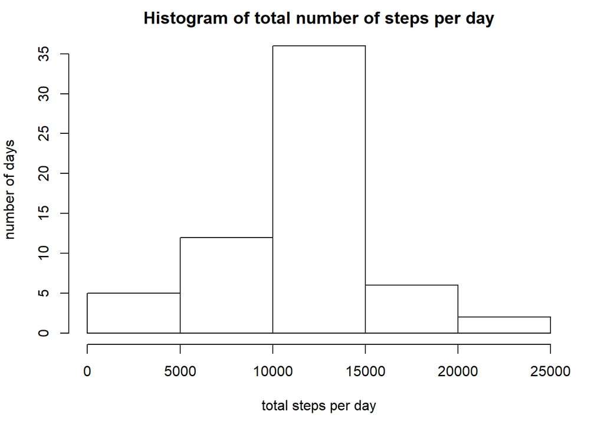

```r
# histogram of total steps per day
par(mar=c(5,4,2,2))
hist(sum.na.impute.step, main="Histogram of total number of steps per day", xlab="total steps per day", ylab="number of days")
```

```r
# report the mean and median
mean(sum.na.impute.step)
```

```
## [1] 10766.19
```

```r
median(sum.na.impute.step)
```

```
## [1] 10766.19
```

[output not shown]

Little is lost by excluding the missing values.

## Are there differences in activity patterns between weekdays and weekends?

1. Create a new factor variable indicating whether it is weekend in the dataset.

```r
weekend<-weekdays(activity.na.impute$date) %in% c("Saturday", "Sunday")
weekend<-as.factor(weekend)
levels(weekend)<-c("weekday", "weekend")
activity.na.impute<-data.frame(activity.na.impute, weekend)
```

2. Make a panel plot of average steps across 61 days in an interval for both weekend and nonweekend.

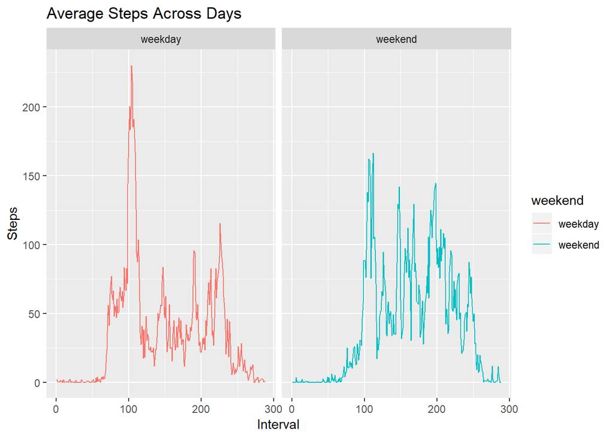

```r
mean.step.na.impute<-aggregate(steps.na.impute ~ interval + weekend, data=activity.na.impute, mean)

library(ggplot2)
ggplot(mean.step.na.impute, aes(x=rep(seq(1:288), 2), y=steps.na.impute, color=weekend))+geom_line()+labs(title="Average Steps Across Days", x="Interval", y="Steps")+facet_wrap(weekend~.)
```